# BAS.MY Johor Bahru: observed vs scheduled bus service

KD44103 Big Data Analytics · Group G12 · Phase 3 results dashboard

24 November 2026

**8,572**GPS records from 103 realtime snapshots

**2,801**stop arrivals inferred by Spark

**28%**arrivals on time (−1 to +5 min)

**41%**arrivals more than 1 min early

**Research question.** How do the buses we can actually see moving (GPS, GTFS-Realtime) compare with the published BAS.MY timetable (static GTFS)? Data window: 2026-11-24 14:31:55 to 2026-11-24 15:27:55 (1 day(s), 2.9 MB raw JSON).

# Pipeline

| Stage | Tool | What happens |
| --- | --- | --- |
| Ingest | Python collector | polls the GTFS-Realtime API every 30 s, decodes protobuf → JSON Lines, partitions by date |
| Store | SQLite (SQL) + Parquet | keyed relational schema for the timetable + Spark outputs; views and report queries in `sql/` |
| Process | **Apache Spark** (PySpark, Spark SQL) | flatten nested JSON, clean, GPS pairs → speeds, stop-arrival inference, headways, 250 m grid |
| Model | Spark MLlib + **R** | delay regression (5 algorithms), grid clustering (4 algorithms), Wilcoxon tests |
| Present | **R** ggplot2 / R Markdown | this dashboard and the report figures |

| Data-quality step | Count |
| --- | --- |
| snapshots (feed versions) | 103 |
| vehicle records (raw) | 8,572 |
| records with no trip_id | 0 |
| records with trip_id not in GTFS | 0 |
| records outside Johor bbox | 0 |
| duplicate (vehicle, timestamp) | 0 |
| clean vehicle records | 8,572 |
| distinct vehicles | 130 |
| distinct trips observed | 155 |
| distinct routes observed | 19 |

# Objective 1 · Speed by route and hour

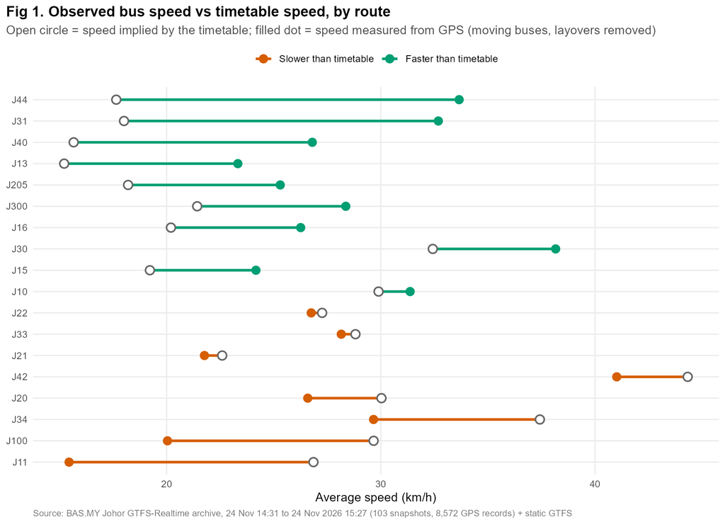

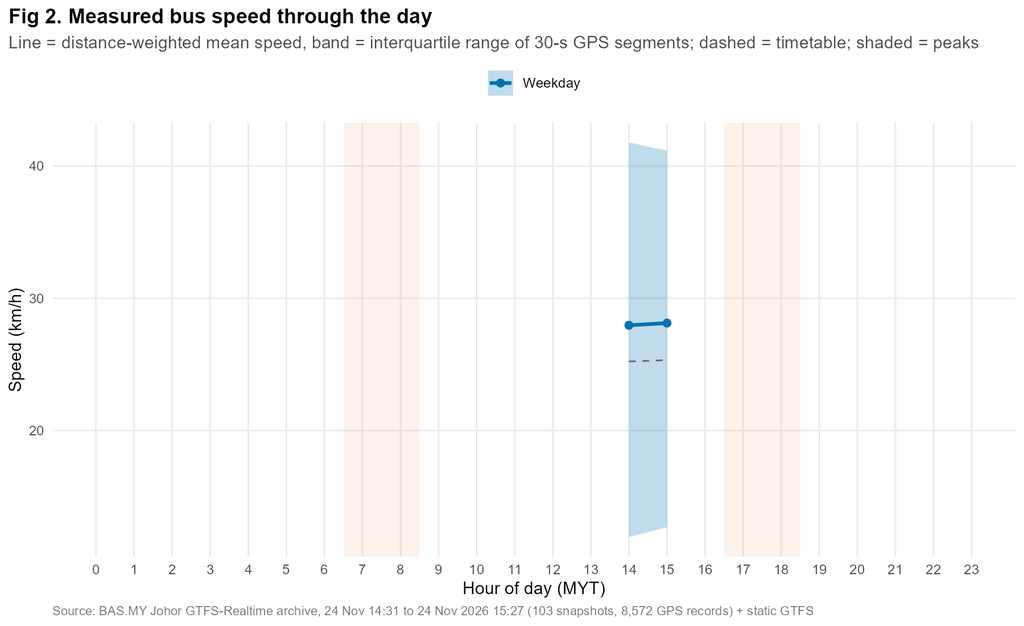

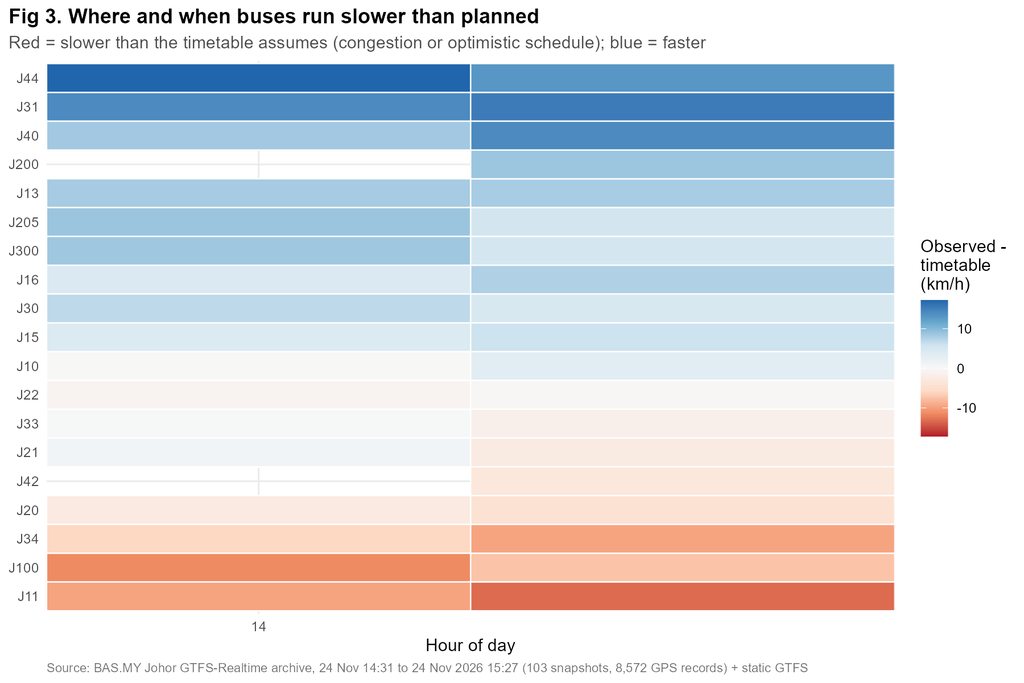

# Objective 2 · Punctuality and service gaps

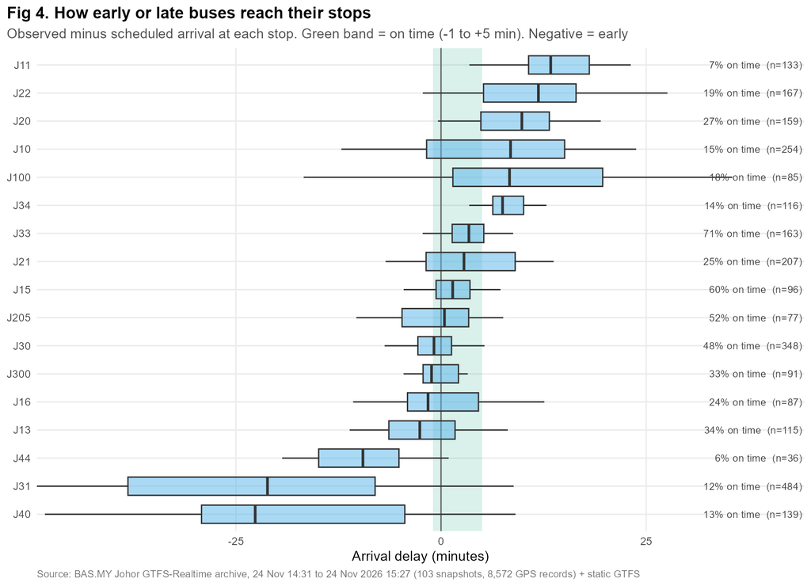

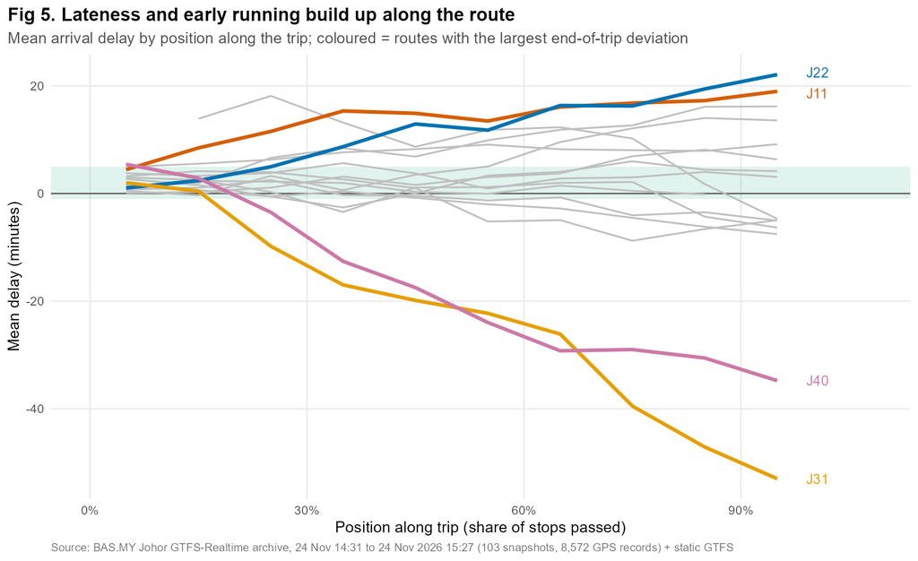

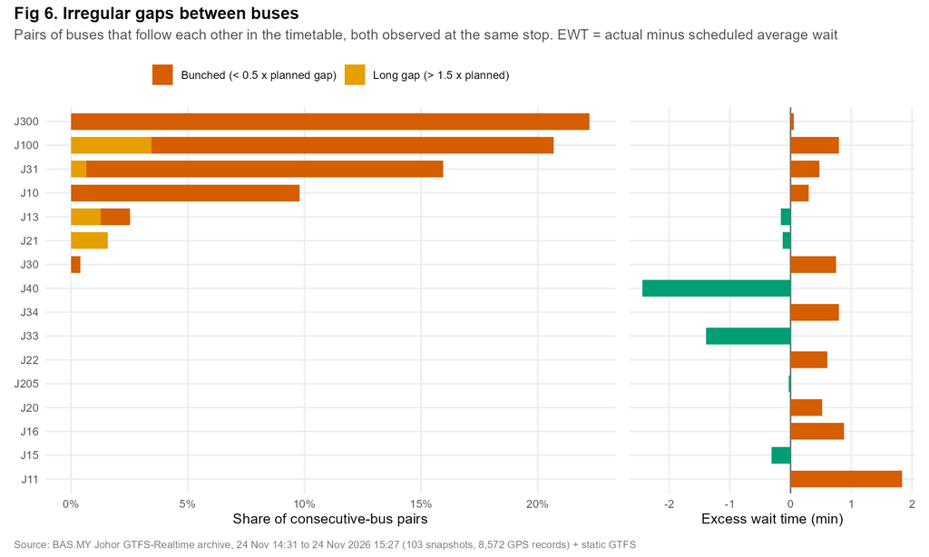

Route scorecard (output of sql/03_queries.sql: route_scorecard)

| Route | Trips/day (sched.) | Trips seen | Mean delay (min) | On time | Early | Late | Bunched | EWT (min) |
| --- | --- | --- | --- | --- | --- | --- | --- | --- |
| J30 | 149 | 13 | -1.07 | 48% | 49% | 3% | 0% | 0.75 |
| J300 | 120 | 8 | 0.98 | 33% | 53% | 14% | 22% | 0.05 |
| J15 | 118 | 8 | 2.10 | 60% | 20% | 20% | 0% | -0.31 |
| J21 | 114 | 10 | 3.60 | 25% | 33% | 42% | 0% | -0.13 |
| J34 | 112 | 10 | 7.72 | 14% | 0% | 86% | 0% | 0.80 |
| J10 | 110 | 14 | 6.43 | 15% | 28% | 56% | 10% | 0.30 |
| J13 | 109 | 8 | -2.29 | 34% | 57% | 9% | 1% | -0.16 |
| J31 | 107 | 15 | -23.63 | 12% | 86% | 2% | 15% | 0.47 |
| J11 | 75 | 7 | 13.84 | 7% | 0% | 93% | 0% | 1.83 |
| J22 | 75 | 8 | 11.43 | 19% | 7% | 75% | 0% | 0.60 |
| J20 | 71 | 6 | 9.23 | 27% | 0% | 73% | 0% | 0.52 |
| J100 | 65 | 6 | 8.46 | 18% | 25% | 58% | 17% | 0.79 |
| J33 | 63 | 6 | 3.35 | 71% | 2% | 27% | 0% | -1.39 |
| J16 | 58 | 5 | -0.14 | 24% | 54% | 22% | 0% | 0.88 |
| J205 | 58 | 5 | -1.07 | 52% | 39% | 9% | 0% | -0.03 |
| J40 | 44 | 6 | -19.01 | 13% | 82% | 5% | 0% | -2.44 |
| J44 | 28 | 4 | -11.36 | 6% | 94% | 0% | NA% | NA |
| J42 | 19 | 2 | 3.24 | 75% | 0% | 25% | NA% | NA |
| J200 | 17 | 1 | -9.44 | 15% | 85% | 0% | NA% | NA |

# Objective 3 · Congestion hotspots

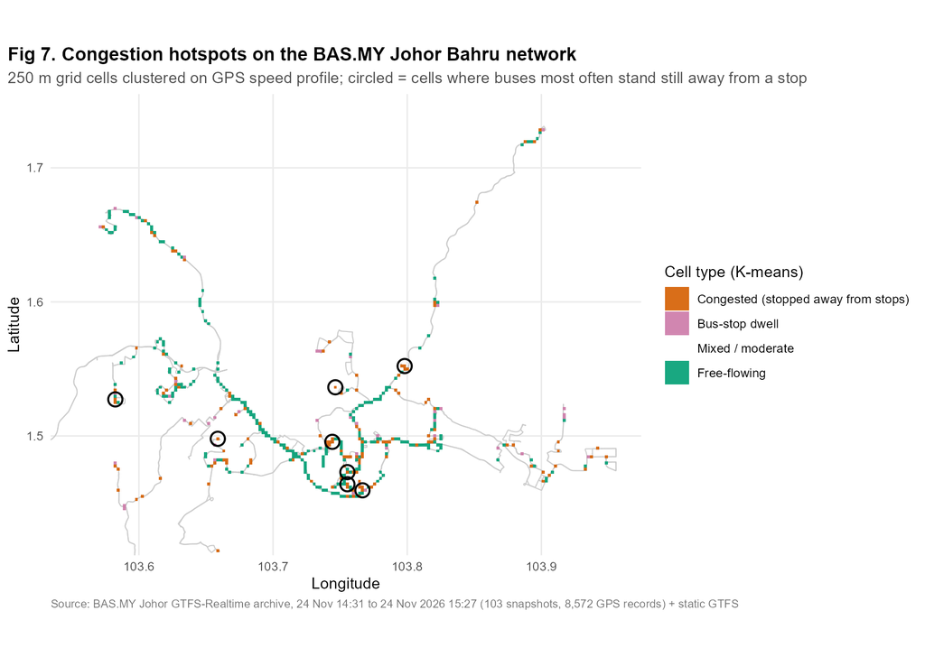

Median profile of each K-means cluster

| Cluster | Cells | Median speed | Stopped away from stop | Dwell at stop |
| --- | --- | --- | --- | --- |
| Bus-stop dwell | 40 | 1.1 | 0% | 47% |
| Congested (stopped away from stops) | 135 | 7.2 | 34% | 0% |
| Free-flowing | 260 | 31.0 | 0% | 0% |

Top congested cells, named by nearest stop (SQL)

| label | lat | lon | n_pairs | p50_speed | share_stopped_offstop | nearest_stop | nearest_stop_m |
| --- | --- | --- | --- | --- | --- | --- | --- |
| Congested (stopped away from stops) | 1.536301 | 103.7464 | 102 | 0.0 | 1.000 | Simpang Jalan Firma 3/1 | 400 |
| Congested (stopped away from stops) | 1.527258 | 103.5824 | 38 | 0.0 | 1.000 | Taman Pulai Mutiara 6 | 29 |
| Congested (stopped away from stops) | 1.497866 | 103.6588 | 35 | 0.2 | 1.000 | HAB TAMAN TAN SRI YAACOB | 132 |
| Congested (stopped away from stops) | 1.495605 | 103.7442 | 110 | 0.2 | 0.927 | Larkin Sentral | 190 |
| Congested (stopped away from stops) | 1.561172 | 103.6184 | 9 | 0.3 | 0.778 | Taman Sri Pulai (Lebuhraya Skudai - Pont | 178 |
| Congested (stopped away from stops) | 1.599608 | 103.8206 | 39 | 0.2 | 0.769 | Perhentian Bas dan Kereta Sewa Ulu Tiram | 270 |
| Congested (stopped away from stops) | 1.493344 | 103.7397 | 12 | 0.5 | 0.750 | OPP DEWAN JKR JOHOR BAHRU | 218 |
| Congested (stopped away from stops) | 1.472995 | 103.9014 | 11 | 0.2 | 0.727 | Opp SMK Pasir Gudang | 542 |
| Congested (stopped away from stops) | 1.459430 | 103.5847 | 7 | 0.2 | 0.714 | Opp Maybank Taman Nusantara | 242 |
| Congested (stopped away from stops) | 1.563433 | 103.7374 | 7 | 1.5 | 0.714 | AEON Dato Onn | 383 |

# Objective 4 · Coverage

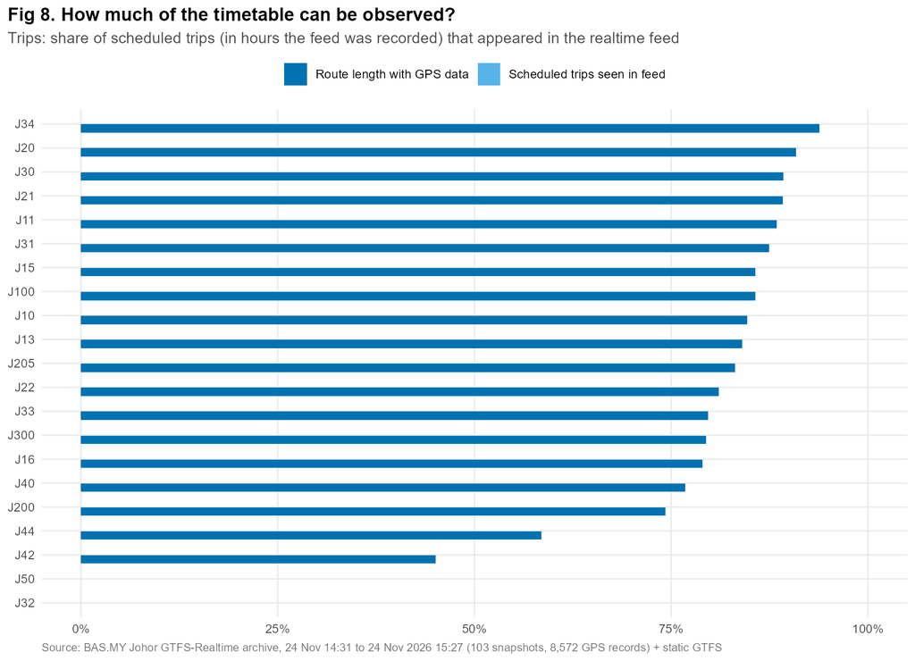

# Algorithm comparison

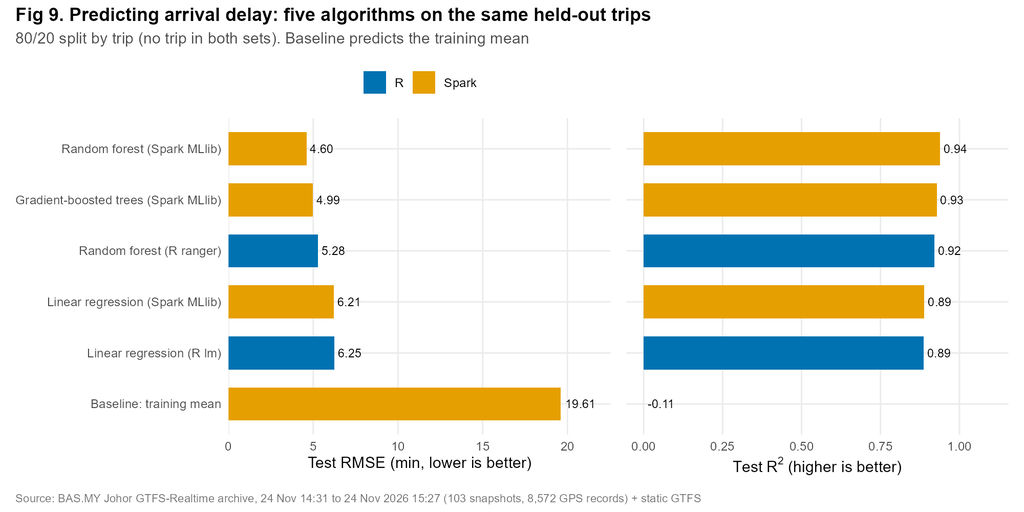

Delay regression, held-out trips

| model | engine | rmse | mae | r2 | train_s |
| --- | --- | --- | --- | --- | --- |
| Random forest (Spark MLlib) | Spark | 4.601 | 3.668 | 0.939 | 8.66 |
| Gradient-boosted trees (Spark MLlib) | Spark | 4.985 | 3.927 | 0.928 | 43.45 |
| Random forest (R ranger) | R | 5.277 | 4.179 | 0.920 | 0.46 |
| Linear regression (Spark MLlib) | Spark | 6.212 | 4.685 | 0.889 | 2.87 |
| Linear regression (R lm) | R | 6.253 | 4.705 | 0.887 | 0.02 |
| Baseline: training mean | Spark | 19.609 | 13.205 | -0.107 | 0.00 |

The best model is **Random forest (Spark MLlib)** (RMSE 4.60 min, R² 0.94), against 19.61 min for the training-mean baseline.

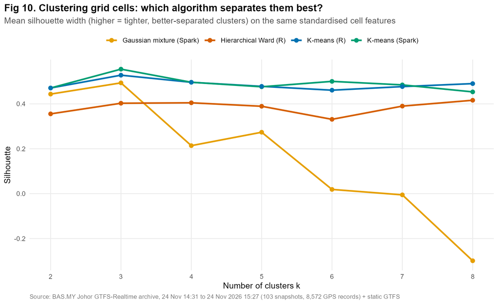

[figure not shown]

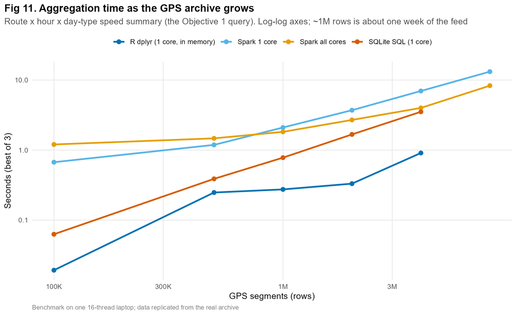

# Limitations

- Arrivals are **inferred** from 30-second GPS fixes (interpolated where the track passes within 60 m of a stop), not recorded.
- Routes or buses missing from the feed cannot be assessed; a missing trip may be a tracking gap rather than a cancellation.
- The timetable has a 1-minute resolution, and every trip uses the `ALLDAY` service, so it does not change for peak hours or weekends.